# Untitled

Allan Sims

2025-01-29

# Mitteparameetriline analüüs

## Üldistatud aditiivne mudel

Üldistatud aditiivne mudel (GAM) on statistiline mudel, mis ühendab lineaarse mudeli omadused aditiivsete funktsioonide abil. Lihtsamalt öeldes on GAM mudel, mis modelleerib funktsioontunnust mitme argumenttunnuse summa abil, kus iga argumenttunnuse mõju funktsioontunnusele modelleeritakse splain funktsiooni abil.

Splain funktsioon on matemaatiline funktsioon, mida kasutatakse andmete interpoleerimiseks ja sujuvaks lähendamiseks. See on tükkhaaval defineeritud polünoom, mis on konstrueeritud nii, et see oleks sujuv ja pidev andmepunktide vahel. See tähendab, et spline funktsioonil ei ole järske hüppeid ega nurki, mis teeb selle ideaalseks tööriistaks sujuvate kõverate ja pindade modelleerimiseks.

Selles näites kasutame R-i paketti `mgcv` GAM mudeli sobitamiseks. Eesmärk on modelleerida puu kõrguse (H) ja diameetri (D) vahelist seost, eeldades, et see seos ei pruugi olla lineaarne.

**1. Andmete laadimine ja ettevalmistamine:**

```r
# Andmete laadimine
puud <- openxlsx::read.xlsx("data/puud.xlsx")

mudelpuud <- subset(puud, H > 0)
# Andmestiku struktuuri vaatamine
str(mudelpuud)
```

```
## 'data.frame':    50 obs. of  4 variables:
##  $ PL: chr  "MA" "KU" "KU" "KU" ...
##  $ D1: num  31.3 22.4 18.4 23.6 27.4 21.7 33.2 25.9 20.3 26.9 ...
##  $ D2: num  31 22.1 17.6 23.9 27.3 21.7 32.3 25.3 20.5 26.5 ...
##  $ H : num  24 22.8 20.4 25.1 24.8 22.3 26.2 27.9 22.3 23.8 ...
```

**3. Mudeli kokkuvõtte vaatamine:**

Saame mudeli kohta detailse kokkuvõtte funktsiooni `summary()` abil:

```r
# Mudeli kokkuvõte
summary(model)
```

```
##
## Family: gaussian
## Link function: identity
##
## Formula:
## H ~ s(D1)
##
## Parametric coefficients:
##             Estimate Std. Error t value Pr(>|t|)
## (Intercept)  24.2840     0.1745   139.2   <2e-16 ***
## ---
## Signif. codes:  0 '***' 0.001 '**' 0.01 '*' 0.05 '.' 0.1 ' ' 1
##
## Approximate significance of smooth terms:
##         edf Ref.df     F p-value
## s(D1) 3.716   4.63 27.46  <2e-16 ***
## ---
## Signif. codes:  0 '***' 0.001 '**' 0.01 '*' 0.05 '.' 0.1 ' ' 1
##
## R-sq.(adj) =   0.72   Deviance explained = 74.2%
## GCV = 1.6802  Scale est. = 1.5217    n = 50
```

Kokkuvõte annab meile informatsiooni mudeli sobivuse kohta, sh:

- **Parametric coefficients:** Kui mudelis on ka lineaarseid komponente, näidatakse siin nende koefitsiendid. Meie näites on siin ainult konstant.
- **Approximate significance of smooth terms:** Siin näeme p-väärtuse hinnangut splainfunktsiooni olulisuse kohta. Madal p-väärtus (<0.05) viitab statistiliselt olulisele mittelineaarsele seosele diameetri ja kõrguse vahel.
- **R-sq.(adj):** Korrigeeritud determinatsioonikordaja näitab, kui suure osa kõrguse varieeruvusest mudel seletab.
- **Deviance explained:** Sarnane determinatsioonikordajale, näitab mudeli poolt seletatud deviantsi osakaalu.

Saame visualiseerida diameetri ja kõrguse vahelist seost funktsiooni `plot()` abil:

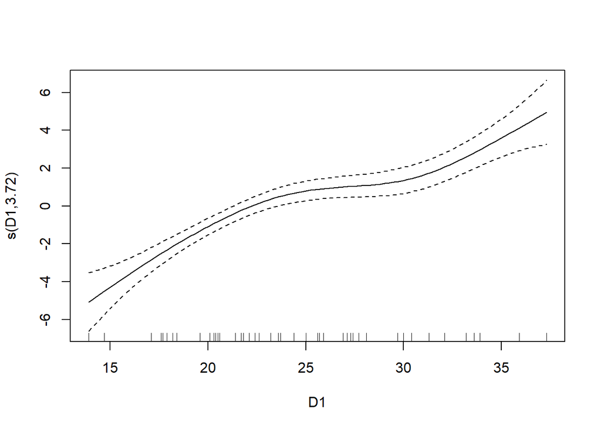

Kõrguse sõltuvus diameetrist

```r
# Mudeli visualiseerimine
plot(model)
```

Saame kasutada mudelit uute puude kõrguse ennustamiseks, andes ette diameetri väärtused funktsiooni `predict()` abil:

```r
# Uute diameetrite väärtused
uued_diameetrid <- data.frame(D1 = c(12, 22, 32))

# Ennustuste tegemine
ennustused <- predict(model, newdata = uued_diameetrid)

# Ennustuste kuvamine
print(ennustused)
```

```
##        1        2        3
## 17.84685 24.18610 26.30129
```

See kood ennustab puu kõrguse, kui diameeter on 12, 22 ja 32 ühikut.

**Kokkuvõte:**

See näide demonstreerib, kuidas R-is kasutada GAM mudelit puu kõrguse ja diameetri vahelise mittelineaarse seose modelleerimiseks. Pakett `mgcv` pakub paindlikke tööriistu GAM mudelite sobitamiseks ja tulemuste interpreteerimiseks. See on vaid lihtne näide ja GAM mudeleid saab laiendada, lisades mudelisse teisi ennustavaid muutujaid, modelleerides interaktsioone ja kasutades erinevaid sujuvaid funktsioone.